# EasyVisa Project

### Gradient Boosting Classifier

```python
gbc = GradientBoostingClassifier(random_state=1)
gbc.fit(X_train,y_train)
```

```
GradientBoostingClassifier(random_state=1)
```

```python
gbc_perf_train = get_score(gbc, X_train, y_train)
print("Training performance \n", gbc_perf_train)
```

```
Training performance
    Accuracy    Recall  Precision        F1
0  0.752915  0.874171   0.781714  0.825362
```

```python
gbc_perf_test = get_score(gbc, X_test, y_test)
print("Training performance \n", gbc_perf_test)
```

```
Training performance
    Accuracy    Recall  Precision        F1
0  0.737964  0.867973   0.769271  0.815647
```

**Despite similar scores, we will perform the hyperparameter tuning in the model to see if it can produce better score.**

```python
gbc_tuned = GradientBoostingClassifier(init=AdaBoostClassifier(random_state=1),random_state=1)

# Grid of parameters to choose from
## add from article
parameters = {
    "n_estimators": [100],
    "subsample":[0.8,0.9],
    "max_features":[0.7]
}

# Type of scoring used to compare parameter combinations
acc_scorer = metrics.make_scorer(metrics.recall_score)

# Run the grid search
grid_obj = GridSearchCV(gbc_tuned, parameters, scoring=acc_scorer,cv=5)
grid_obj = grid_obj.fit(X_train, y_train)

# Set the clf to the best combination of parameters
gbc_tuned = grid_obj.best_estimator_

# Fit the best algorithm to the data.
gbc_tuned.fit(X_train, y_train)
```

```
GradientBoostingClassifier(init=AdaBoostClassifier(random_state=1),
                           max_features=0.7, random_state=1, subsample=0.9)
```

```python
gbc_perf_train_tuned = get_score(gbc_tuned, X_train, y_train)
print("Training performance \n", gbc_perf_train_tuned)
```

```
Training performance
    Accuracy    Recall  Precision        F1
0  0.753644  0.878116   0.780497  0.826434
```

```python
gbc_perf_test_tuned = get_score(gbc_tuned, X_test, y_test)
print("Training performance \n", gbc_perf_test_tuned)
```

```
Training performance
    Accuracy    Recall  Precision        F1
0  0.740712  0.874633     0.7689  0.818365
```

**Despite tuning the model, the scores did not improve much. This could be because the parameters were limited.** **Let's look at the feature importance.**

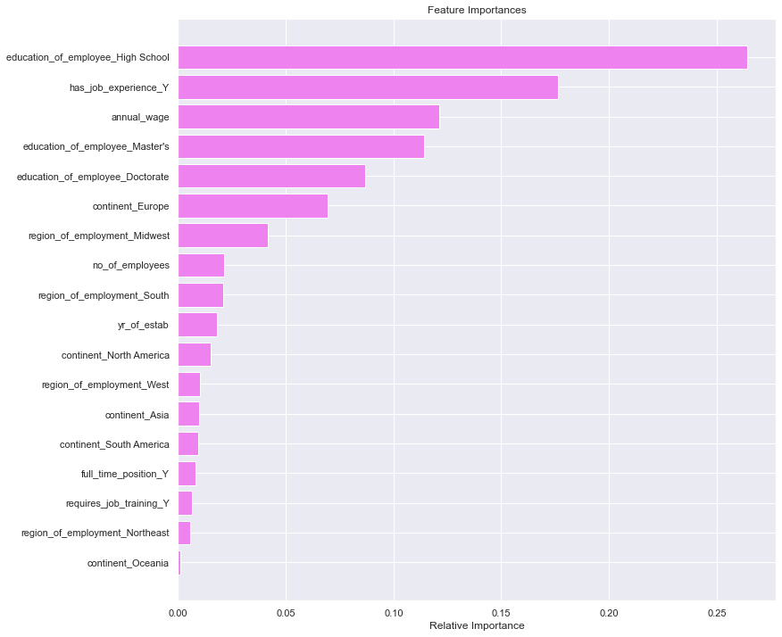

```python
importances = gbc_tuned.feature_importances_
indices = np.argsort(importances)
feature_names = list(X.columns)

plt.figure(figsize=(12,12))
plt.title('Feature Importances')
plt.barh(range(len(indices)), importances[indices], color='violet', align='center')
plt.yticks(range(len(indices)), [feature_names[i] for i in indices])
plt.xlabel('Relative Importance')
plt.show()
```

- Gradient boosting has High School education listed as most important feature followed by job experience.

### XGBoosting Classifier

```python
xgb = XGBClassifier(random_state=1,eval_metric='logloss')
xgb.fit(X_train,y_train)
```

```
XGBClassifier(base_score=0.5, booster='gbtree', colsample_bylevel=1,
              colsample_bynode=1, colsample_bytree=1, enable_categorical=False,
              eval_metric='logloss', gamma=0, gpu_id=-1, importance_type=None,
              interaction_constraints='', learning_rate=0.300000012,
              max_delta_step=0, max_depth=6, min_child_weight=1, missing=nan,
              monotone_constraints='()', n_estimators=100, n_jobs=8,
              num_parallel_tree=1, predictor='auto', random_state=1,
              reg_alpha=0, reg_lambda=1, scale_pos_weight=1, subsample=1,
              tree_method='exact', validate_parameters=1, verbosity=None)
```

```python
xgb_perf_train = get_score(xgb, X_train, y_train)
print("Training performance \n", xgb_perf_train)
```

```
Training performance
    Accuracy    Recall  Precision        F1
0   0.83965  0.928817   0.846142  0.885554
```

```python
xgb_perf_test = get_score(xgb, X_test, y_test)
print("Training performance \n", xgb_perf_test)
```

```
Training performance
    Accuracy    Recall  Precision        F1
0  0.724097  0.850539   0.763361  0.804596
```

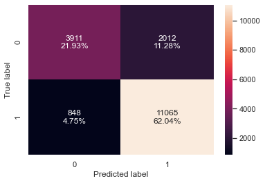

```python
confusion_matrix_sklearn(xgb, X_train, y_train)
```

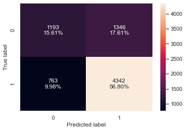

```python
confusion_matrix_sklearn(xgb, X_test, y_test)
```

**The f1 score in training data is higher than in test data, that means it has overfitted the model for prediction. We will try to tune the model below.

```python
xgb_tuned = XGBClassifier(random_state=1,eval_metric='logloss')

# Grid of parameters to choose from
## add from
parameters = {
    "n_estimators": np.arange(10,100,20),
    "scale_pos_weight":[0,1,2,5],
    "subsample":[0.5,0.7,0.9,1],
    "learning_rate":[0.01,0.1,0.2,0.05],
    "gamma":[0],
    "colsample_bytree":[0.5,0.7,0.9],
    "colsample_bylevel":[0.5,0.7,0.9],
    "nthread":[8],
    "scale_pos_weight": [1]
}

# Type of scoring used to compare parameter combinations
acc_scorer = metrics.make_scorer(metrics.recall_score)

# Run the grid search
grid_obj = GridSearchCV(xgb_tuned, parameters,scoring=acc_scorer,cv=5)
grid_obj = grid_obj.fit(X_train, y_train)

# Set the clf to the best combination of parameters
xgb_tuned = grid_obj.best_estimator_

# Fit the best algorithm to the data.
xgb_tuned.fit(X_train, y_train)
```

```
XGBClassifier(base_score=0.5, booster='gbtree', colsample_bylevel=0.5,
              colsample_bynode=1, colsample_bytree=0.5,
              enable_categorical=False, eval_metric='logloss', gamma=0,
              gpu_id=-1, importance_type=None, interaction_constraints='',
              learning_rate=0.01, max_delta_step=0, max_depth=6,
              min_child_weight=1, missing=nan, monotone_constraints='()',
              n_estimators=10, n_jobs=8, nthread=8, num_parallel_tree=1,
              predictor='auto', random_state=1, reg_alpha=0, reg_lambda=1,
              scale_pos_weight=1, subsample=1, tree_method='exact',
              validate_parameters=1, verbosity=None)
```

**Checking the performance of the tuned model**

```python
xgb_perf_train_tuned = get_score(xgb_tuned, X_train, y_train)
print("Training performance \n", xgb_perf_train_tuned)
```

```
Training performance
    Accuracy    Recall  Precision        F1
0  0.711538  0.971208   0.706694  0.818101
```

```python
xgb_perf_test_tuned = get_score(xgb_tuned, X_test, y_test)
print("Training performance \n", xgb_perf_test_tuned)
```

```
Training performance
    Accuracy    Recall  Precision        F1
0  0.698456  0.967483   0.697796  0.810802
```

- **The F1-score is reduced from untuned model, however the training and test dataset are giving similar results, which means the model is correctly predicting and well fitted.**
- **Lets look at the confusion matrix.**

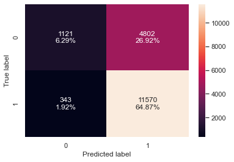

```python
confusion_matrix_sklearn(xgb_tuned,X_train, y_train)
```

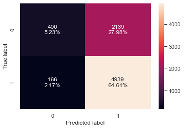

```python
confusion_matrix_sklearn(xgb_tuned,X_test, y_test)
```

**We can see in the confusion matrix as well that training and test dataset are predicting almost similar outcomes implying the model is correctly fitted.**

**Looking at the features**

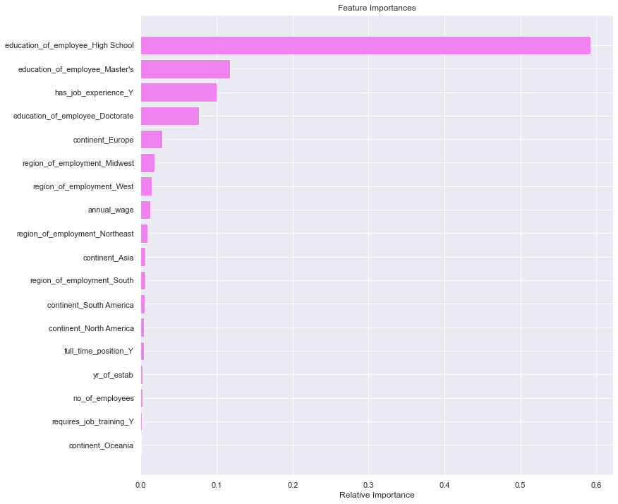

```python
importances = xgb_tuned.feature_importances_
indices = np.argsort(importances)
feature_names = list(X.columns)

plt.figure(figsize=(12,12))
plt.title('Feature Importances')
plt.barh(range(len(indices)), importances[indices], color='violet', align='center')
plt.yticks(range(len(indices)), [feature_names[i] for i in indices])
plt.xlabel('Relative Importance')
plt.show()
```

**XGB model is showing the `High School Education` as most important factor and by far than other predictors.**

### Stacking Classifier

**Building stacking model with the tuned models - decision tree, random forest, and gradient boosting, then use XGBoost to get the final prediction.**

```python
estimators=[('Decision Tree', estimator),('Random Forest', rf_estimator_tuned),
           ('Gradient Boosting', gbc_tuned)]
final_estimator=XGBClassifier(random_state=1)
```

```python
stacking_estimator=StackingClassifier(estimators=estimators, final_estimator=final_estimator,cv=5)
stacking_estimator.fit(X_train,y_train)
```

[output not shown]

```
StackingClassifier(cv=5,
                   estimators=[('Decision Tree',
                                DecisionTreeClassifier(class_weight='balanced',
                                                       max_depth=10,
                                                       min_impurity_decrease=0.0001,
                                                       random_state=1,
                                                       splitter='random')),
                               ('Random Forest',
                                RandomForestClassifier(max_features=0.7,
                                                       max_samples=0.3,
                                                       min_samples_leaf=9,
                                                       n_estimators=150,
                                                       random_state=1)),
                               ('Gradient Boosting',
                                GradientBoostingClassifier(in...
                                                 interaction_constraints=None,
                                                 learning_rate=None,
                                                 max_delta_step=None,
                                                 max_depth=None,
                                                 min_child_weight=None,
                                                 missing=nan,
                                                 monotone_constraints=None,
                                                 n_estimators=100, n_jobs=None,
                                                 num_parallel_tree=None,
                                                 predictor=None, random_state=1,
                                                 reg_alpha=None,
                                                 reg_lambda=None,
                                                 scale_pos_weight=None,
                                                 subsample=None,
                                                 tree_method=None,
                                                 validate_parameters=None,
                                                 verbosity=None))
```

```python
stacking_estimator_perf_train = get_score(stacking_estimator, X_train, y_train)
print("Training performance \n", stacking_estimator_perf_train)
```

```
Training performance
    Accuracy    Recall  Precision        F1
0  0.752131  0.874339    0.78081  0.824932
```

```python
stacking_estimator_perf_test = get_score(stacking_estimator, X_test, y_test)
print("Training performance \n", stacking_estimator_perf_test)
```

```
Training performance
    Accuracy    Recall  Precision        F1
0  0.732601  0.864251   0.765573  0.811925
```

**The model is performing extremely well in terms of fitting the data as scores on all front are similar between training and test dataset.**

## Model Performance Comparison and Conclusions

```python
# training performance comparison

models_train_comp_df = pd.concat(
    [dtree_model_perf_train.T,
dtree_estmodel_perf_train.T,
bagging_model_perf_train.T,
bagging_model_perf_train_tuned.T,
rf_estimator_perf_train.T,
rf_model_perf_train_tuned.T,
abc_score_train.T,
abc_perf_train_tuned.T,
gbc_perf_train.T,
gbc_perf_train_tuned.T,
xgb_perf_train.T,
xgb_perf_train_tuned.T,
stacking_estimator_perf_train.T
],
    axis=1,
)

models_train_comp_df.columns = [
    "Decision Tree",
    "Decision Tree Tuned",
    "Bagging_Model",
    "Bagging_Model_Tuned",
    "Random Forest Estimator",
    "Random Forest Tuned",
    "Adaboost Classifier",
    "Adaboost Tuned",
    "Gradient Boost Estimator",
    "Gradient Boost Tuned",
    "XGB",
    "XGB Tuned",
    "Stacking Classifier"
]

print("Training performance comparison:")
models_train_comp_df
```

```
Training performance comparison:
```

|  | Decision Tree | Decision Tree Tuned | Bagging_Model | Bagging_Model_Tuned | Random Forest Estimator | Random Forest Tuned | Adaboost Classifier | Adaboost Tuned | Gradient Boost Estimator | Gradient Boost Tuned | XGB | XGB Tuned | Stacking Classifier |
| --- | --- | --- | --- | --- | --- | --- | --- | --- | --- | --- | --- | --- | --- |
| Accuracy | 1.0 | 0.728022 | 0.983909 | 0.667919 | 0.999944 | 0.771529 | 0.734806 | 0.734806 | 0.752915 | 0.753644 | 0.839650 | 0.711538 | 0.752131 |
| Recall | 1.0 | 0.753798 | 0.984974 | 1.000000 | 0.999916 | 0.885084 | 0.885587 | 0.885587 | 0.874171 | 0.878116 | 0.928817 | 0.971208 | 0.874339 |
| Precision | 1.0 | 0.824004 | 0.990880 | 0.667919 | 1.000000 | 0.795774 | 0.758066 | 0.758066 | 0.781714 | 0.780497 | 0.846142 | 0.706694 | 0.780810 |
| F1 | 1.0 | 0.787339 | 0.987918 | 0.800901 | 0.999958 | 0.838056 | 0.816880 | 0.816880 | 0.825362 | 0.826434 | 0.885554 | 0.818101 | 0.824932 |

- Untuned model was literally copying the dataset line by line, upon tuning, parameters limited the access of model.
- Parameters were not flexible and wide-ranged.
- Something is wrong in the approach of the modeling.

## Actionable Insights and Recommendations

- As we see, F1 scores across all the models is above 80% except than in `Tuned Decision Tree`, it means our model is able to minimize False Negatives and False Positives for 80% of the time.
- Some of the predictors such as `annual wage` and `number of employees` are highly skewed.
- Visa approval rate are higher for highly educated employees and less for `High School Educated`in our EDA, which was further validated by feature importance graph in various Models as `High school Educated` was on top.
- As the models are suggesting, while assessing for Visas, education and experience is to be given most priority.